# Measuring Location and Spread

TEMBA Statistics 2026

## We’re going to play a game

- You have to guess the sale price of a randomly selected house in one of two ZIP codes.
- You can pick the ZIP code.

## Pick your ZIP code

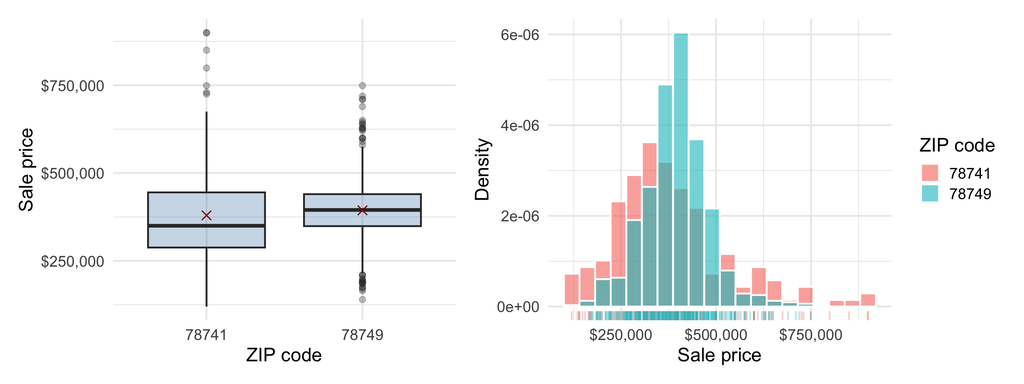

**Which zip, and what’s your guess?**

## The mean

- For the 134 sales in ZIP 78752, the mean price is $370,804: add up all 134 prices and divide by 134.
- In notation, $\bar{x} = \frac{1}{n}\sum_{i=1}^{n} x_i$.

## Subscripts and summation

| $i$ | $x_i$ (sale price) |
| --- | --- |
| 1 | $419,000 |
| 2 | $429,000 |
| 3 | $575,000 |
| 4 | $210,000 |

- A subscript labels *which* observation: $x_1$ is the first sale price, $x_2$ the second, $x_i$ “the $i$-th one.” With $n$ observations, $i$ runs from 1 to $n$.
- $\sum$ (capital sigma, for “sum”) means “add up”:
  $$\sum_{i=1}^{4} x_i = x_1 + x_2 + x_3 + x_4 = \$419,000 + \$429,000 + \$575,000 + \$210,000 = \$1,633,000.$$
- Put $n$ in place of 4 to add up the whole column; $\frac{1}{n}\sum_{i=1}^{n} x_i$ is that total divided by $n$ — the mean.

## The median

- The median price in 78752 is $351,478: the middle value when the prices are sorted, with half the sales below and half above.
- Unlike the mean, the median doesn’t care how extreme the extremes are.

## Mean vs. median

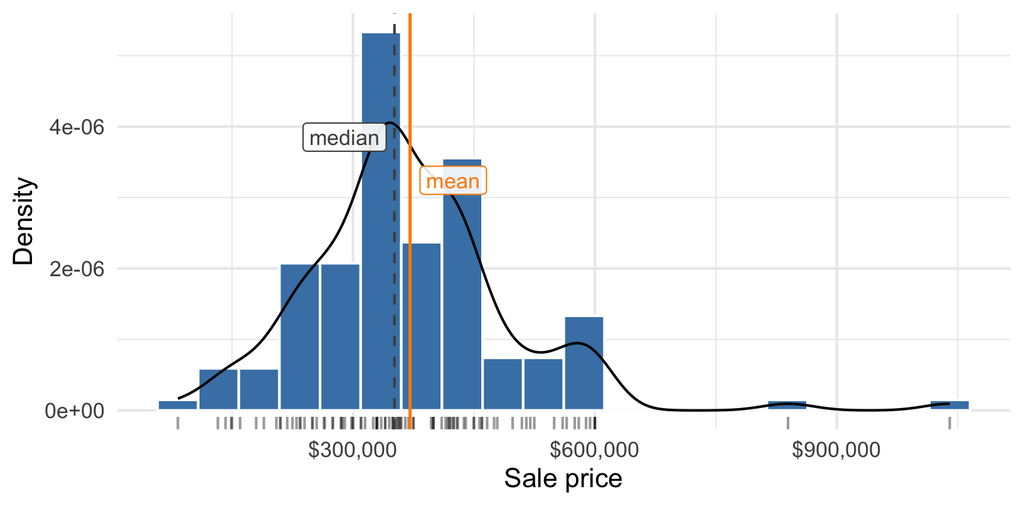

The mean sits above the median because a few high-priced homes drag the average up. Report both, and pay attention to the gap — a large gap signals skewness.

# Measures of spread

## Back to the game

- Your best guess is the mean or the median.
- Whichever you choose, prices in 78741 vary more around that center, so your prediction error will tend to be larger there.
- Measures of spread quantify how *un*predictable a variable is.

## Standard deviation

The **standard deviation** measures the typical distance of an observation from the mean:

$$s = \sqrt{\frac{1}{n-1}\sum_{i=1}^{n} (x_i - \bar{x})^2}$$

- We square the deviations so positive and negative ones don’t cancel, then take the square root to get back to the original units.
- For 78749 the standard deviation is $85,141; for 78741 it is $151,824 — about 1.8 times the standard deviation in 78749.

## Variance

- The **variance** is the standard deviation squared, $s^2$.
- Its units — dollars-squared here — are impossible to picture, so we report the standard deviation when we want a readable number.
- Variance earns its keep as a building block inside other calculations.

## Standard deviation measures unpredictability

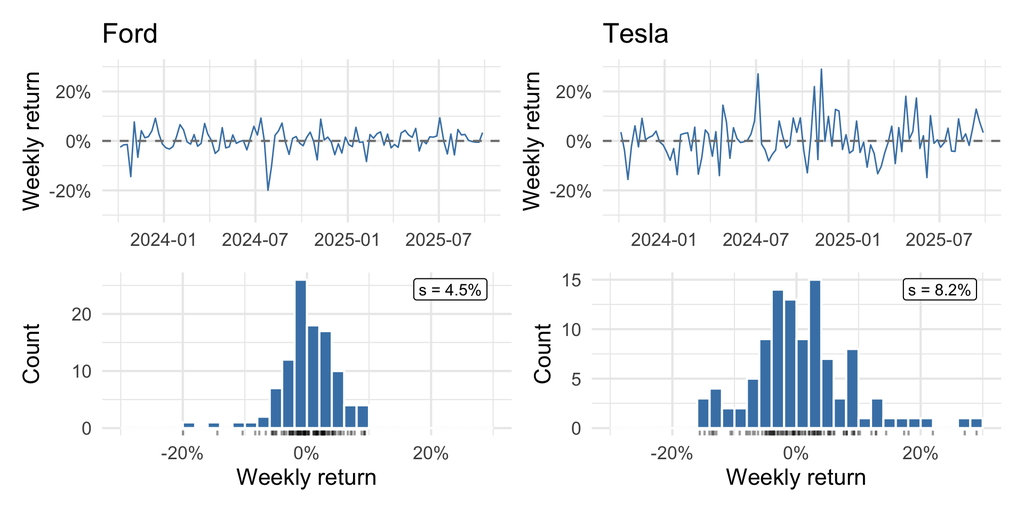

## Tesla is harder to predict

- Ford: $s$ = 4.5%. Tesla: $s$ = 8.2%, about 1.8 times larger.
- A typical Tesla week lands that much farther from its average, up or down.
- Guess next week’s return for each stock and you will miss by more with Tesla. That is what the standard deviation measures.

## The interquartile range

- The **IQR** is the distance between the 75th and 25th percentiles, $\text{IQR} = Q3 - Q1$: the width of the middle half of the data.
- It comes to $91,000 in 78749 and $157,000 in 78741.
- Like the median, the IQR ignores how extreme the extremes are.

# Linear transformations

## Changing units

A **linear transformation** multiplies a variable by a constant, adds a constant, or does both: $y = ax + b$. Every value gets the same rescaling and the same shift.

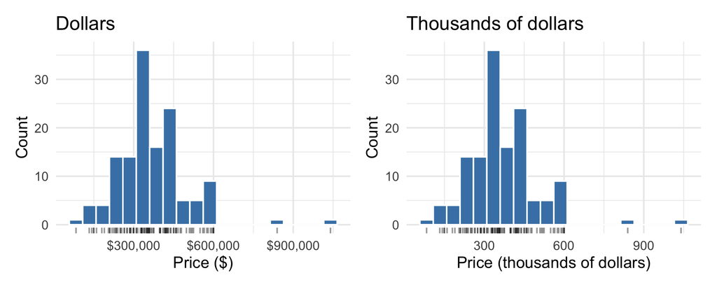

The shape is identical; only the axis labels change.

## Shifting: mean-centering

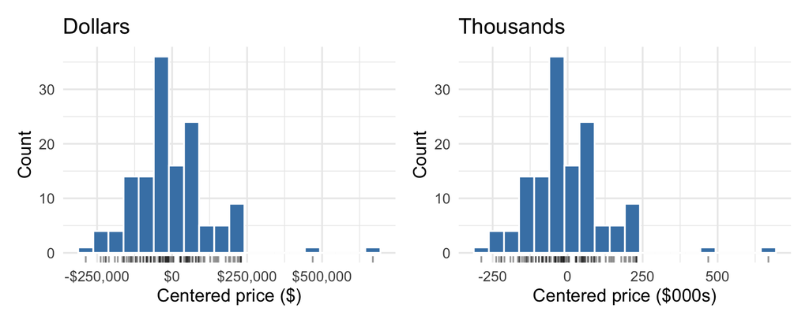

Subtracting the mean shifts the distribution to center on zero; the shape is unchanged.

## What happens to the summaries?

If $y_i = a x_i + b$ for every observation, where $a$ and $b$ are constants, then

$$\bar{y} = a\bar{x} + b, \qquad \text{median}(y) = a\,\text{median}(x) + b,$$

$$s_y = |a|\,s_x, \qquad s^2_y = a^2\,s^2_x.$$

Adding $b$ shifts the center and leaves the spread alone; multiplying by $a$ scales both the center and the spread (and the spread doesn’t care about the sign of $a$).